```
Embarked   C   Q    S
Survived
0         75  47  427
1         93  30  217
```

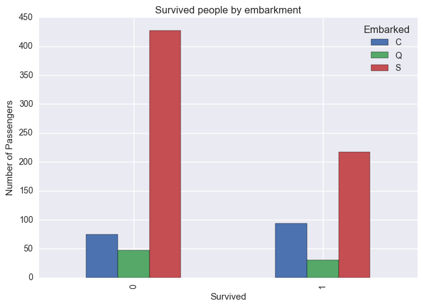

```python
double = titanic.groupby(['Survived','Embarked']).size().unstack()
print double
double.plot(kind='bar',title="Survived people by embarkment")
plt.ylabel('Number of Passengers')
plt.show()
```

1. Above plot gives us analysis as per the survival and embarkment destinations and both's relation.
2. Plot shows that People of City S survived most. This also gives us insights about what might be our probability of saving as per our embarkment destinations.
3. Plot also proves a point that visualizations are more helpful in analysis than tables as we have both table and plot of same data but plot is more helpful.
4. Plot also gives interesting fact that people embarking to city C survived more than the ones who dont survived embarking to same city. While this is not true for other two cities. In both cases more people didnt survived. This might be because more rich and first class people are embarking to city C or any other reason might be behing their more survival rate.

```python
parch = titanic.groupby(['Survived']).sum()['Parch']
sibsp = titanic.groupby(['Survived']).sum()['SibSp']
print parch
print sibsp
```

```
Survived
0    181
1    159
Name: Parch, dtype: int64
Survived
0    304
1    162
Name: SibSp, dtype: int64
```

```
[ 81 468 233 109]
```

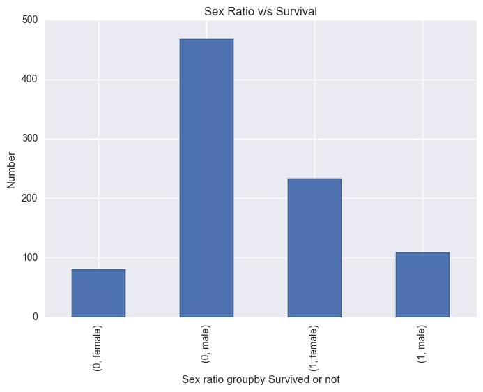

```python
sex_ratio = titanic.groupby(['Survived','Sex']).size()
print sex_ratio.values
sex_ratio.plot(kind="bar",title='Sex Ratio v/s Survival')
plt.xlabel('Sex ratio groupby Survived or not')
plt.ylabel('Number')
plt.show()
```

```
Survived    0    1
Sex
female     81  233
male      468  109
```

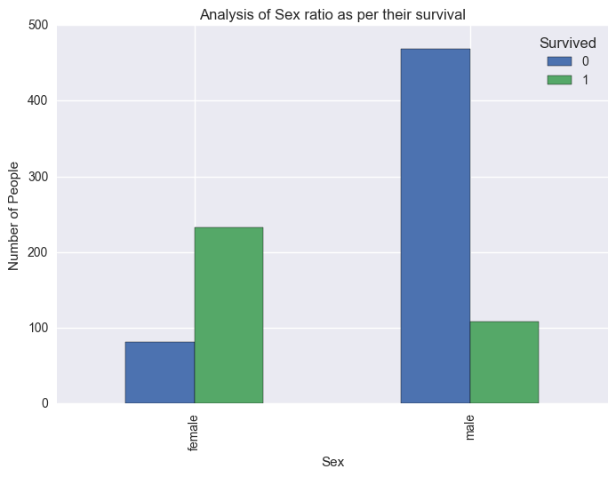

```python
ratio = pd.crosstab(titanic['Sex'], titanic['Survived'])
print ratio
ratio.plot(kind='bar',title="Analysis of Sex ratio as per their survival")
plt.ylabel('Number of People')
plt.show()
```

1. Above classification gives us detail analysis of how many people survived as per their sex. This is same as sex_ratio data obtained by group by method. Methods are different but conclusion and answers are same.
2. More number of males are passengers but it is interesting to see more female's survived than male. It might be because of preferences first given to women and children while saving or another thing might be more women would be there in 1st class.

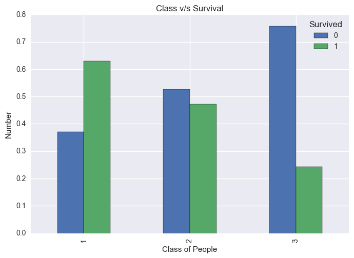

```python
survival = pd.crosstab((titanic['Pclass']), titanic['Survived'], normalize='index')
survival.plot(kind='bar',title='Class v/s Survival')
plt.xlabel('Class of People')
plt.ylabel('Number')
plt.show()
```

1. Above analysis gives us analysis about conditional survival probabilites as per the class ticket person had.This shows that if you were of class 1 then there were around 62% chances of you survivng.
2. This clearly leads us to think that rich people were saved first because the survival rate is decreasing as per the class. Evne 2nd Class has around 48% chances of survival and lastly 3rd class with just 25% chances of survival.

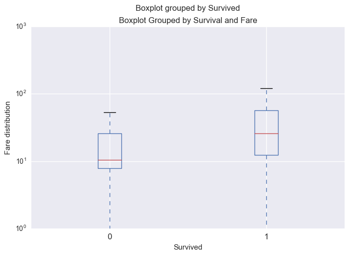

```python
titanic.boxplot(column=['Fare'],by=['Survived']).set_yscale('log')
plt.title('Boxplot Grouped by Survival and Fare')
plt.xlabel('Survived')
plt.ylabel('Fare distribution')
plt.show()
```

# # Conclusion:

1. The analysis showed that people of Class 1 survived more than people of other class.
2. It also showed the survival of females more than male.
3. The limitation is that we can use this analysis for future conditional survival probabilites but they dont assure that these things might again work in fvaour of surviving.
4. Also this analysis doesnt helps in finding reasons of sinking of Titanic ship.
5. This analysis also shows that majority of Class 1 people were embarked to city S than other destinations. Also majority of people had their embarkment destination as S which can help further to get more tourists and people on future voyages if we get embarkement to city S.